# Análise de Variância Multivariada (MANOVA)

José O Siqueira (siqueira@usp.br) Paulo SP Silveira (silveira@usp.br)

23 julho 2024 17:55h

```r
invisible(Sys.setlocale("LC_CTYPE", "pt_BR.UTF-8"))
invisible(Sys.setlocale("LC_ALL", "pt_BR.UTF-8"))
```

```r
options(warn=-1)
suppressMessages(library(knitr, warn.conflicts=FALSE))
suppressMessages(library(readxl, warn.conflicts=FALSE))
suppressMessages(library(psych, warn.conflicts=FALSE))
suppressMessages(library(emmeans, warn.conflicts=FALSE))
suppressMessages(library(multcomp, warn.conflicts=FALSE))
suppressMessages(library(ggplot2, warn.conflicts=FALSE))
suppressMessages(library(GGally, warn.conflicts=FALSE))
suppressMessages(library(effects, warn.conflicts=FALSE))
suppressMessages(library(effectsize, warn.conflicts=FALSE))
suppressMessages(library(tidyr, warn.conflicts=FALSE))
suppressMessages(library(MASS, warn.conflicts=FALSE))
suppressMessages(library(car, warn.conflicts=FALSE))
suppressMessages(library(MVN, warn.conflicts=FALSE))
suppressMessages(library(heplots, warn.conflicts=FALSE))
suppressMessages(library(rrcov, warn.conflicts=FALSE))
suppressMessages(library(DescTools, warn.conflicts=FALSE))
suppressMessages(library(SHT, warn.conflicts=FALSE))
suppressMessages(library(mvdalab, warn.conflicts=FALSE))
source("eiras.friendlycolor.R")
source("eiras.correg.R")
source("eiras.bivCI.R")
source("eiras.showdataframe.R")
source("eiras.numeric.summary.R")
source("eiras.bartitle.R")
```

# Material

- HTML de R Markdown em [`RPubs`](http://rpubs.com/josiqueira/)
- Arquivos em [`GitHub`](https://github.com/josiqueira/EstatMedR)

# Objetivos

- Conceituar MANOVA, distinguindo-a de ANOVA e ANCOVA.
- Conceituar e testar as suposições da MANOVA.
- Proceder com a análise descritiva numérica e gráfica dos dados.
- Formular e implementar:
  - $T^2$ de Hotelling
  - MANOVA unifatorial independente
  - MANCOVA
- Determinar as significâncias estatística e prática do efeito do fator.

# O que é MANOVA

Técnicas estatísticas multivariadas são extensões das técnicas univariadas e bivariadas para situações nas quais temos mais do que uma variável dependente ou medida:

- $T^2$ de Hotelling: testar centróides de medidas intervalares multivariadas observadas em duas condições independentes.
- MANOVA: Análise de Variância Multivariada Independente
- MANCOVA: Análise de Covariância Multivariada
- rmMANOVA unifatorial: Análise de Variância Multivariada para Medidas Repetidas (um fator intraparticipantes)
- MANOVA mista (um fator entre participantes e um fator intraparticipantes)

O teste $T^2$ de Hotelling é o primeiro e mais básico dos testes multivariados. Originalmente, era possível testar a igualdade de dois centróides multivariados populacionais.

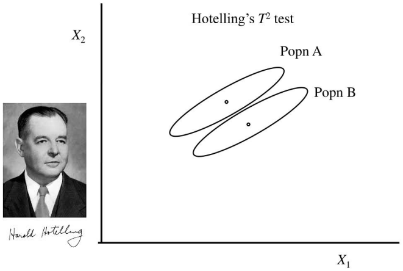

Em MANOVA, o efeito de um fator com três ou mais condições pode ser testado e, em MANCOVA, incluiremos covariáveis. Com estes testes, completamos o uso do modelo linear geral (GLM).

## Por que utilizar MANOVA?

Um construto pode ser medido por meio de alguns itens intervalares, por exemplo, compleição que poderia ser decomposta com medidas de massa corporal total (MCT) e estatura. Em geral, as medidas são correlacionadas. Além disto, para indicar o uso de MANOVA independente, deve existir um fator como, por exemplo, sexo (masculino e feminino). Queremos determinar se existe diferença de compleição masculina e feminina.

Diferentemente dos testes feitos anteriomente, a variável de desfecho (VD), aqui, não é composta de uma medida única: neste exemplo a VD é a combinação das medidas de MCT e estatura. O fator nominal que explicaria esta diferença é sexo. Outros fatores (nominais) ou covariáveis (intervalares) também podem ser adicionados a estes modelos como variáveis explicativas.

Da mesma forma que ocorre com testes *t* em relação à ANOVA, tentar substituir uma MANOVA pela realização de um conjunto de ANOVAs aumenta a probabilidade do erro do tipo I (falso-positivo). MANOVA permite tratar o conjunto em uma única análise, aproveitando as correlações entre as medidas.

# Os testes básicos e o GLM

Os testes básicos podem ser vistos como manifestações do GLM com graus crescentes de complexidade:

- Teste t  
  1 medida intervalar & 1 fator entre ou intraparticipantes com duas condições
- ANOVA unifatorial  
  1 medida intervalar & 1 fator com três ou mais condições
- Regressão univariada simples  
  1 medida intervalar & 1 VE intervalar
- ANCOVA unifatorial simples  
  1 medida intervalar & 1 fator e 1 VE intervalar (covariável)
- Regressão univariada múltipla  
  1 medida intervalar & 2 ou mais VEs intervalares
- Regressão multivariada múltipla  
  2 ou mais medidas intervalares & 2 ou mais VEs intervalares
- $T^2$ de Hotelling  
  2 ou mais medidas intervalares & 1 fator entre ou intraparticipantes (duplamente multivariada) com duas condições
- MANOVA unifatorial  
  2 ou mais medidas intervalares & 1 fator entre ou intraparticipantes (duplamente multivariada) com três ou mais condições
- MANCOVA unifatorial simples  
  2 ou mais medidas intervalares & 1 fator entre ou intraparticipantes (duplamente multivariada) e 1 VE intervalar (covariável)
- …

Modelos podem evoluir daqui em diante. Se as medidas fossem estatura e MCT, e as variáveis explicativas fossem sexo e raça (ambas nominais), teremos uma MANOVA independente bifatorial. Se adicionarmos idade e tempo de prática esportiva (intervalares), é uma MANCOVA independente bifatorial múltipla. Caso as medidas sejam repetidas, uma MANCOVA bifatorial múltipla relacionada.

# A lógica da MANOVA

Na ANOVA, particionamos a variância da medida que pode ser atribuída aos efeitos principais e de interação das VIs. Na MANOVA, a situação é mais complexa porque há mais de uma medida envolvida e, portanto, há uma matriz de covariância compondo a variabilidade total das medidas. Em nosso exemplo, a variabilidade total depende da variância da estatura, da variância da massa corporal e da covariância entre elas. Além disto, se há um fator com dois níveis (e.g., sexos masculino e feminino), então há dois destes conjuntos de variância a serem levados em conta.

No processo de cálculo da MANOVA, as diversas medidas são internamente convertidas em um escore intervalar similar ao que acontece com um modelo de análise fatorial unidimensional e utiliza este escore, chamado de combinação linear ótima das medidas, criando uma única VD para a análise. A análise informa se existe(m) efeito(s) das VIs na combinação linear das VDs.

# As suposições subjacentes ao uso da MANOVA

As duas grandes suposições são de normalidade multivariada e homocedasticidade multivariada das medidas nos níveis do fator.

# MANOVA unifatorial independente

## MANOVA para uma condição

O exemplo de estatura e MCT tem um fator entre participantes (sexo) com dois níveis e duas medidas (estatura e MCT).

Vamos supor, no entanto, que estejamos interessados apenas nos participantes do sexo masculino. Adiante verificaremos se estes estudantes são brasileiros típicos de acordo com a medida de Moreira et al. (2013) que indica, em média, estatura de $172~cm$ e MCT de $76.68~kg$.

O arquivo de dados usado neste caso é `Adm2008.rds`.

```r
Dados <- data.frame(readxl::read_excel("Adm2008.xlsx"))
Dados$Nome <- factor(Dados$Nome)
Dados$Sexo <- factor(Dados$Sexo)
Dados$Estatura <- Dados$Estatura*100
saveRDS(Dados, "Adm2008.rds")
```

Iniciando pela estatística descritiva, sugere-se o que está implementado em `demo_Adm2008Masc_descritiva.R`:

```
options(warn=-1) # disable warnings

source("eiras.friendlycolor.R")
source("eiras.correg.R")
source("eiras.bivCI.R")
source("eiras.showdataframe.R")
source("eiras.numeric.summary.R")
source("eiras.bartitle.R")

H0.M <- c(172,76.68)
alfa <- 0.05
B <- 1e3

colM <- friendlycolor(7) # azul
pchM <- 24
alpha <- 0.05

cat(bartitle("Data"))
Dados <- readRDS("Adm2008.rds")
Masc <- subset(Dados, Sexo=="Masculino", select=c(Estatura, MCT))
showdataframe(Masc, head=5, tail=3)
print(summary(Masc))

cat(bartitle("Summary"))

print(psych::describe(Masc[,c("Estatura","MCT")], data=Masc))
cat(bartitle("Correlation matrix",3))
print(cor(Masc), digits=2)
cat(bartitle("Covariance matrix",3))
print(cov(Masc), digits=2)

correg(Masc$Estatura,
       Masc$MCT,
       method="raw", conf.band = FALSE, lowess=FALSE,
       alpha=0.05, B=0,
       xlab="Estatura (cm)", ylab="MCT (kg)",
       main="Estudante de Administração Masculino",
       col=colM, bg="transparent", pch=pchM,
       show.equation = FALSE, suppress.text = TRUE)

# elipses de confianca do centroide populacional
lines(bivCI(s = var(Masc),
            xbar = colMeans(Masc),
            n = nrow(Masc),
            alpha = alpha, m = 1e4),
      type = "l", col = colM, lwd = 2)
cx <- mean(Dados$Estatura[Dados$Sexo=="Masculino"], na.rm=TRUE)
cy <- mean(Dados$MCT[Dados$Sexo=="Masculino"], na.rm=TRUE)
points(cx,cy,pch=21,col=colM,bg=colM)
points(H0.M[1],H0.M[2],pch=10)
text(H0.M[1],H0.M[2],expression(H[0]),pos=2)
text(cx,cy, pos=3, "M", col=colM)

options(warn=0) # enable warnings
```

```
----
Data
----
 Estatura MCT
 188      82
 191      83
 172      58
 172      82
 182      77
 ...      ...
 178      92
 168      71
 176      78
    Estatura          MCT
 Min.   :156.0   Min.   : 48.00
 1st Qu.:172.0   1st Qu.: 66.00
 Median :176.0   Median : 73.00
 Mean   :176.4   Mean   : 74.47
 3rd Qu.:182.0   3rd Qu.: 82.00
 Max.   :193.0   Max.   :105.00

-------
Summary
-------
         vars  n   mean    sd median trimmed   mad min max range  skew kurtosis
Estatura    1 51 176.35  8.08    176  176.49  8.90 156 193    37 -0.17    -0.36
MCT         2 51  74.47 12.10     73   73.93 11.86  48 105    57  0.39    -0.30
           se
Estatura 1.13
MCT      1.69

        ------------------
        Correlation matrix
        ------------------
         Estatura  MCT
Estatura     1.00 0.65
MCT          0.65 1.00

        -----------------
        Covariance matrix
        -----------------
         Estatura MCT
Estatura       65  63
MCT            63 146
```

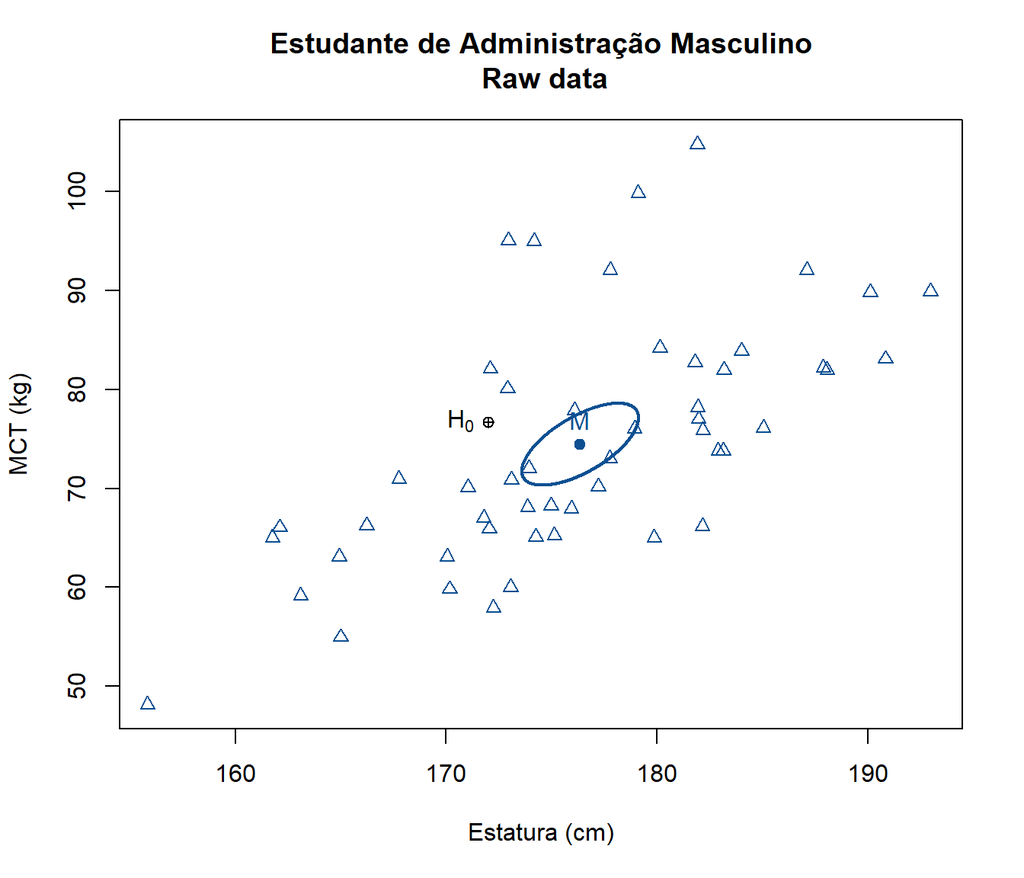

A novidade é a região elíptica de confiança de 95% do centroíde populacional. Como a hipótese nula está fora desta região elíptica, podemos esperar que a hipótese nula será rejeitada adiante.

### Suposições

A MANOVA supõe normalidade multivariada das medidas em cada tratamento (neste caso bivariada porque só temos duas medidas: estatura e MCT, nas condições masculino e feminino). Os testes estão implementados em `demo_Adm2008Masc_normalidade.R`:

```
source("eiras.bartitle.R")

options(warn=-1) # disable warnings

Dados <- readRDS("Adm2008.rds")
Masc <- subset(Dados, Sexo=="Masculino", select=c(Estatura, MCT))

result <- MVN::mvn(data = Masc,
                   # R=5e4,
                   # mvnTest = "energy",
                   mvnTest = "hz",
                   univariateTest = "SF",
                   showOutliers=TRUE)
cat(bartitle("Binormality test"))
print(result$multivariateNormality)
cat(bartitle("Normality test"))
print(result$univariateNormality)
cat(bartitle("Multivariate Outlier"))
print(result$multivariateOutliers)
options(warn=0) # enable warnings
```

```
----------------
Binormality test
----------------
           Test       HZ    p value MVN
1 Henze-Zirkler 1.125764 0.01046938  NO

--------------
Normality test
--------------
             Test  Variable Statistic   p value Normality
1 Shapiro-Francia Estatura     0.9872    0.7697    YES
2 Shapiro-Francia    MCT       0.9781    0.3907    YES

--------------------
Multivariate Outlier
--------------------
NULL
```

Estes testes foram realizados com `MVN::mvn` e mostram os testes de uninormalidade e binormalidade. Para o nível de significância de 5%.

Isoladamente, as distribuições são consideradas normais. Houve rejeição da binormalidade para o grupo Masculino (mas não seria rejeitada com $\alpha=1\%$). No entanto, a amostra tem 51 homens e podemos invocar o teorema central do limite.

### Aplicação do teste

Admitindo que as medidas relatadas em Moreira et al. (2013) são estimativas da população brasileira, as hipóteses nula e alternativa são:

$$H_0: \left[ \mu_{Est}~~~\mu_{MCT}
\right] = \left[ 172~cm~~~76.68~kg \right]$$
$$H_1: \left[ \mu_{Est}~~~\mu_{MCT} \right] \ne
\left[ 172~cm~~~76.68~kg \right]$$

Implementado em `demo_MANOVA_umacondicao.R`:

```
source("eiras.bartitle.R")
source("eiras.bivCI.R")

options(warn=-1) # disable warnings

H0.M <- c(172,76.68)
alfa <- 0.05
B <- 1e4

Dados <- readRDS("Adm2008.rds")
Masc <- subset(Dados, Sexo=="Masculino", select=c(Estatura, MCT))
rm(Dados)

p <- dim(Masc)[2]
n.M <- dim(Masc)[1]
cov.M <- cov(Masc)
mean.M <- colMeans(Masc)
Sinv.M <- solve(cov.M)
F.M <- (n.M*(n.M-p)/((n.M-1)*p))*
       (mean.M-H0.M)%*%Sinv.M%*%(mean.M-H0.M)
p.M <- 1-pf(q=F.M,df1=p,df2=n.M-p)
cat("\nMANOVA para uma condição:\n", sep="")
cat("\tF(",p,",",n.M-p,") = ",F.M,", p = ",p.M,"\n", sep="")

T2One <- MVTests::OneSampleHT2(Masc,
                               mu=H0.M,
                               alpha=alfa)
summary(T2One)

# 'mcd' for minimum covariance determinant estimator
print(rrcov::T2.test(Masc,
               mu = H0.M,
               conf.level = 1-alfa,
               method="mcd"))

T2crit <- ((n.M-1)*p/(n.M-p))*qf(1-alfa, p, n.M-p)
eigen_result <- eigen(cov.M)
eigvl <- eigen_result$values
a <- sqrt(T2crit*eigen_result$values[1]/n.M) # (5-19)
b <- sqrt(T2crit*eigen_result$values[2]/n.M) # (5-19)
theta <- atan2(eigen_result$vectors[2, 1], eigen_result$vectors[1, 1])
theta_seq <- seq(0, 2 * pi, length.out = 100)
ellipse_x <- mean.M[1] + a * cos(theta_seq) * cos(theta) -
  b * sin(theta_seq) * sin(theta)
ellipse_y <- mean.M[2] + a * cos(theta_seq) * sin(theta) +
  b * sin(theta_seq) * cos(theta)
plot(ellipse_x, ellipse_y, type = "l", xlim=c(170,180),
     xlab="Estatura (m)",
     ylab="MCT (kg)",
     main="Região elíptica de confiança de 95%\nEstudante de Administração Masculino",
     col="black")
points(mean.M[1], mean.M[2], col = "black", pch = 19)
points(H0.M[1], H0.M[2], pch=3, col="black")
text(H0.M[1], H0.M[2], pos=1, expression(H[0]))
text(mean.M[1],mean.M[2], pos=2, "M", col="black")

mvdalab::MVcis(Masc,
               level=1-alfa,
               Vars2Plot=c(1, 2),
               include.zero=FALSE)
```

```
MANOVA para uma condição:
    F(2,49) = 19.34467, p = 6.421062e-07
       One Sample Hotelling T Square Test

Hotelling T Sqaure Statistic = 39.47892
 F value = 19.345 , df1 = 2 , df2 = 49 , p-value: 6.42e-07

                  Descriptive Statistics

        Estatura      MCT
N      51.000000 51.00000
Means 176.352941 74.47059
Sd      8.076691 12.09852


                Detection important variable(s)

             Lower     Upper    Mu0 Important Variables?
Estatura 173.46882 179.23706 172.00               *TRUE*
MCT       70.15031  78.79087  76.68                FALSE

    One-sample Hotelling test (Reweighted MCD Location)

data:  Masc
T2 = 113.557, F = 45.465, df1 = 2.000, df2 = 25.687, p-value =
3.641e-09
alternative hypothesis: true mean vector is not equal to (172, 76.68)'

sample estimates:
             Estatura      MCT
MCD x-vector 176.2609 71.97826
```

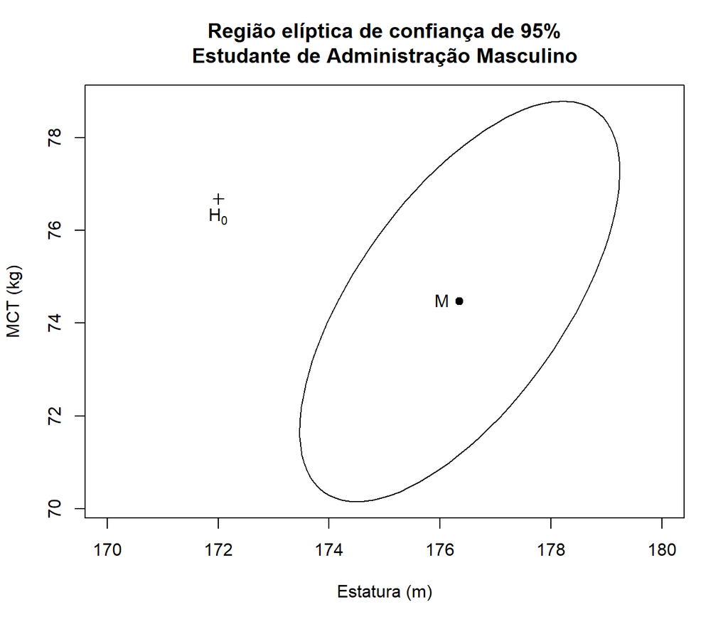

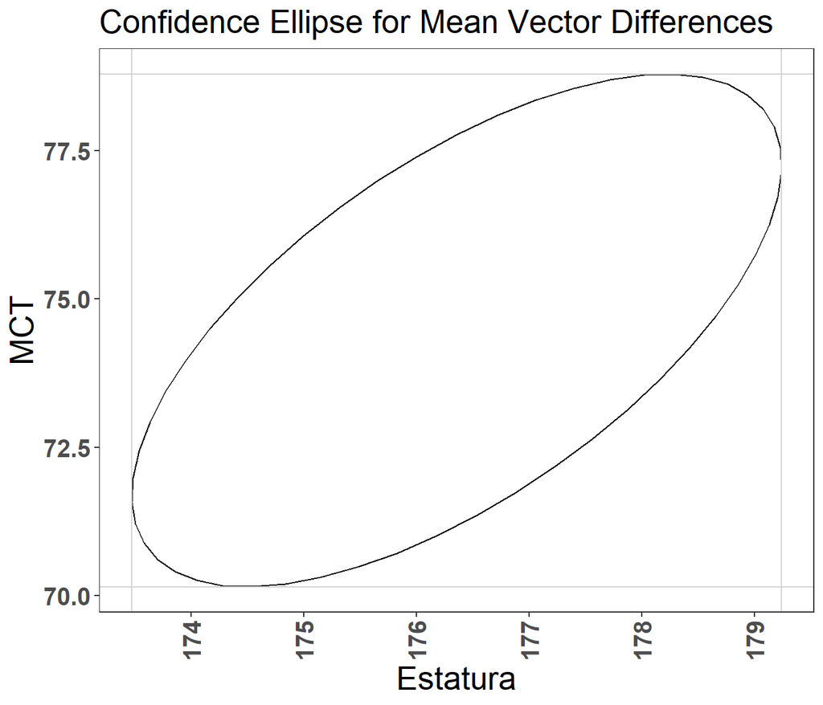

```
              [,1]      [,2]
Estatura 173.46882 179.23706
MCT       70.15031  78.79087
```

Rejeita-se $H_0$ para qualquer nível de significância convencional. Os estudantes de administração de 2008 têm compleição média diferente da população brasileira geral de 2013.

## MANOVA com duas condições independentes

O exemplo de estatura e MCT tem um fator entre participantes (sexo) e duas medidas (estatura e MCT). Iniciando pela estatística descritiva, sugere-se o que está implementado em `demo_Adm2008_descritiva.R`:

```
options(warn=-1) # disable warnings

source("eiras.friendlycolor.R")
source("eiras.correg.R")
source("eiras.bivCI.R")
source("eiras.showdataframe.R")
source("eiras.numeric.summary.R")
source("eiras.bartitle.R")

colM <- friendlycolor(7) # azul
colF <- friendlycolor(30) # vermelho
pchM <- 24
pchF <- 21

alpha <- 0.05

cat(bartitle("Data"))
Dados <- readRDS("Adm2008.rds")
Dados <- Dados[, c("Sexo","Estatura","MCT")]
showdataframe(Dados, head=5, tail=3)

cat(bartitle("Summary"))

cat(bartitle("Masculino",2))
cat(bartitle("Estatura",3))
print(numeric.summary(Dados$Estatura[Dados$Sexo=="Masculino"]))
cat(bartitle("MCT",3))
print(numeric.summary(Dados$MCT[Dados$Sexo=="Masculino"]))

dt_tmp <- data.frame(Dados$Estatura[Dados$Sexo=="Masculino"],
                     Dados$MCT[Dados$Sexo=="Masculino"])
names(dt_tmp) <- c("Estatura","MCT")
cat(bartitle("Correlation matrix",3))
print(cor(dt_tmp), digits=2)
cat(bartitle("Covariance matrix",3))
print(cov(dt_tmp), digits=2)

cat(bartitle("Feminino",2))
cat(bartitle("Estatura",3))
print(numeric.summary(Dados$Estatura[Dados$Sexo=="Feminino"]))
```

[output cut: 66 more lines]

```
                     Dados$MCT[Dados$Sexo=="Feminino"])
names(df_tmp) <- c("Estatura","MCT")
df_tmp <- df_tmp[!is.na(df_tmp$Estatura),]
df_tmp <- df_tmp[!is.na(df_tmp$MCT),]
lines(bivCI(s = var(df_tmp),
            xbar = colMeans(df_tmp),
            n = nrow(df_tmp),
            alpha = alpha/2, m = 10000),
      type = "l", col = colF, lwd = 2)
cx <- mean(Dados$Estatura[Dados$Sexo=="Feminino"], na.rm=TRUE)
cy <- mean(Dados$MCT[Dados$Sexo=="Feminino"], na.rm=TRUE)
points(cx,cy,pch=21,col=colF,bg=colF)
text(cx,cy, pos=2, "F", col=colF)

options(warn=0) # enable warnings
```

```
----
Data
----
 Sexo      Estatura MCT
 Feminino  161      53
 Feminino  156      50
 Feminino  172      60
 Feminino  157      44
 Feminino  168      57
 ...       ...      ...
 Masculino 178      92
 Masculino 168      71
 Masculino 176      78

-------
Summary
-------

    ---------
    Masculino
    ---------

        --------
        Estatura
        --------
 Min. 1st Qu. Median 3rd Qu. Max.     Mean  St.Dev.  n NA
  156     172    176     182  193 176.3529 8.076691 51  0

        ---
        MCT
        ---
 Min. 1st Qu. Median 3rd Qu. Max.     Mean  St.Dev.  n NA
   48      66     73      82  105 74.47059 12.09852 51  0

        ------------------
        Correlation matrix
        ------------------
         Estatura  MCT
Estatura     1.00 0.65
MCT          0.65 1.00
```

[output cut: 32 more lines]

```
        Covariance matrix
        -----------------
         Estatura MCT
Estatura       46  27
MCT            27  38
          item    group1 vars  n   mean    sd median trimmed   mad min max
Estatura1    1  Feminino    1 38 164.13  6.80  164.0  164.22  8.15 150 178
Estatura2    2 Masculino    1 51 176.35  8.08  176.0  176.49  8.90 156 193
MCT1         3  Feminino    2 38  54.63  6.19   53.5   54.47  5.93  43  70
MCT2         4 Masculino    2 51  74.47 12.10   73.0   73.93 11.86  48 105
          range  skew kurtosis   se
Estatura1    28 -0.18    -0.81 1.10
Estatura2    37 -0.17    -0.36 1.13
MCT1         27  0.34    -0.48 1.00
MCT2         57  0.39    -0.30 1.69
```

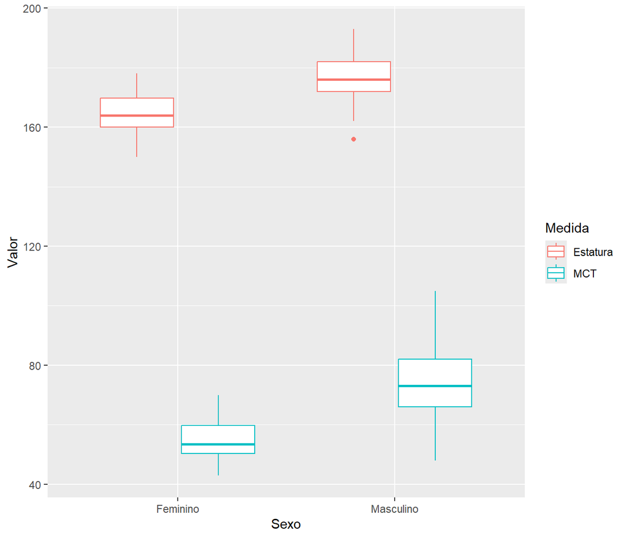

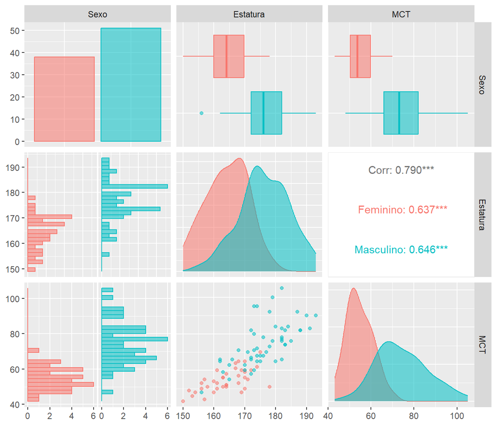

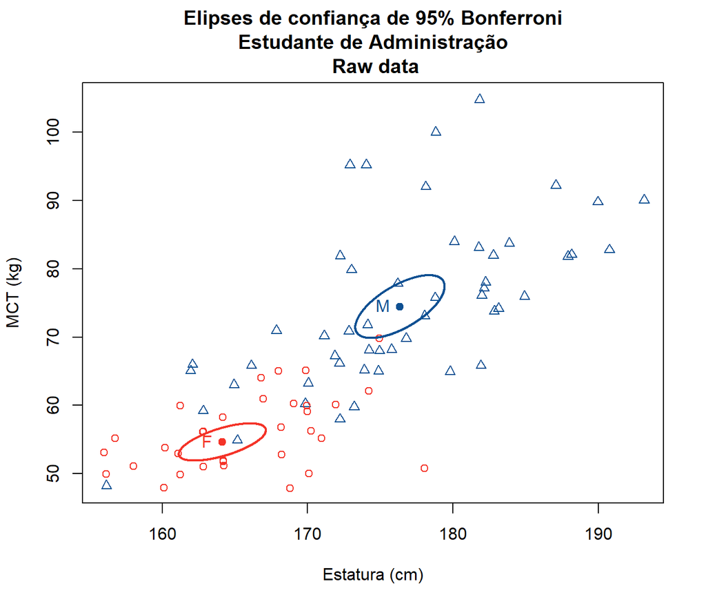

Este gráfico mostra o plano das medidas brutas. As observações para os dois grupos foram representados separadamente. Assinalamos o centróide (um par ordenado) para cada grupo.

As regiões elípticas de confiança de 95% dos centróides populacionais podem ser vistos como uma extensão bivariada do intervalo de confiança de 95% das médias populacionais de estatura e MCT combinadas. Podemos perceber que as elipses dos dois grupos estão distantes: quando não há sobreposição, podemos esperar que a hipótese nula de igualdade dos centróides populacionais será rejeitada.

### Suposições

#### Normalidade multivariada e univariada

Implementado em `demo_Adm2008_normalidade.R`:

```
source("eiras.bartitle.R")

options(warn=-1) # disable warnings

Dados <- readRDS("Adm2008.rds")
Dados <- Dados[, c("Sexo","Estatura","MCT")]

result <- MVN::mvn(data = Dados,
                   subset="Sexo",
                   # R=5e4,
                   # mvnTest = "energy",
                   mvnTest = "hz",
                   univariateTest = "SF")
print(result$multivariateNormality)
print(result$univariateNormality)
options(warn=0) # enable warnings
```

```
$Feminino
           Test        HZ   p value MVN
1 Henze-Zirkler 0.2874337 0.8769151 YES

$Masculino
           Test       HZ    p value MVN
1 Henze-Zirkler 1.125764 0.01046938  NO

$Feminino
             Test  Variable Statistic   p value Normality
1 Shapiro-Francia Estatura     0.9819    0.6938    YES
2 Shapiro-Francia    MCT       0.9809    0.6575    YES

$Masculino
             Test  Variable Statistic   p value Normality
1 Shapiro-Francia Estatura     0.9872    0.7697    YES
2 Shapiro-Francia    MCT       0.9781    0.3907    YES
```

Estes testes foram feitos com `MVN::mvn` e mostram os testes de uninormalidade e binormalidade em cada nível do fator. Para o nível de significância de 5%. Isoladamente, as distribuições são consideradas normais. Houve rejeição apenas da binormalidade para o grupo Masculino (mas não seria rejeitada com $\alpha=1\%$). No entanto, a amostra tem 51 homens e 38 mulheres, e podemos apelar para o teorema central do limite.

“O teste da suposição de multinormalidade, em geral, é necessário para amostra pequena. Se a amostra é suficientemente grande (maior que ‘20 + número de medidas’ para cada condição entre participantes), o TCL entra em ação e a suposição de multinormalidade não é mais necessária.”

> Johnson & Wichern, 2007, p. 294

#### Homocedasticidade multivariada

Avaliamos a homogeneidade das matrizes de covariância. Implementado em `demo_Adm2008_homocedasticidade.R`:

```
source("eiras.bartitle.R")
Sys.setlocale("LC_CTYPE", "pt_BR.UTF-8")
Sys.setlocale("LC_ALL", "pt_BR.UTF-8")

options(warn=-1) # disable warnings

Dados <- readRDS("Adm2008.rds")

print(res <- heplots::boxM(Dados[,c("Estatura","MCT")], Dados$Sexo))
plot(res, main="Estudante de Administração\nEstatura e MCT")

options(warn=0) # enable warnings
```

```
    Box's M-test for Homogeneity of Covariance Matrices

data:  Dados[, c("Estatura", "MCT")]
Chi-Sq (approx.) = 19.918, df = 3, p-value = 0.0001765
```

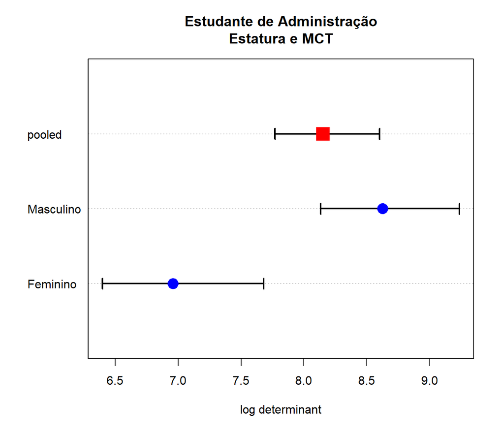

Há heterocedasticidade entre os níveis do fator, porém…

“… com amostras razoavelmente grandes, os testes de médias ou de efeito de tratamentos por MANOVA são bastante robustos à não normalidade. Assim, o teste M de Box pode rejeitar a hipótese nula em alguns casos sem normalidade sem prejuízo para MANOVA. Além disso, com tamanhos de amostra iguais, alguma diferença nas matrizes de covariância têm pouco efeito na MANOVA. Para resumir, podemos decidir continuar com os testes de MANOVA habituais, mesmo que o teste M de Box leve à rejeição da hipótese nula.”

> Johnson & Wichern, 2007, p. 291-6

### Aplicação do teste

A hipótese nula a seguir é a igualdade dos centróides populacionais. Formalmente é:

$$H_0: \left[ \mu^{F}_{Est}~
\;\mu^{F}_{MCT} \right] = \left[ \mu^{M}_{Est}~\;\mu^{M}_{MCT}
\right]$$
$$H_1: \left[
\mu^{F}_{Est}~\;\mu^{F}_{MCT} \right] \ne \left[
\mu^{M}_{Est}~\;\mu^{M}_{MCT} \right]$$

A matriz que conjuga Estatura e MCT para cada um dos sexos é a representação da compleição. Portanto, as hipóteses nula e alternativa podem ser reescritas como:

$$H_0: \text{Compleição Média Feminina} =
\text{Compleição Média Masculina}$$
$$H_1: \text{Compleição Média Feminina} \ne
\text{Compleição Média Masculina}$$

Implementado em `demo_MANOVA_independente.R`:

```
source("eiras.bartitle.R")

options(warn=-1) # disable warnings

cat(bartitle("Data"))
Dados <- readRDS("Adm2008.rds")
Dados <- Dados[, c("Sexo","Estatura","MCT")]

cat(bartitle("T^2 de Hotelling (homocedástico)"))
# Solução 1: DescTools::HotellingsT2Test
# T.2 é F
print(DescTools::HotellingsT2Test(cbind(Estatura,MCT)~Sexo,
                                  data = Dados))

cat(bartitle("MANOVA (homocedástica)"))
# Solução 2: manova
fit <- manova(cbind(Estatura,MCT)~Sexo,
              data = Dados)
print(anv <- car::Anova(fit,
                        test="Pillai"),
      digits=3)
alpha <- 0.05
eta2 <- effectsize::eta_squared(anv,
                                partial=TRUE,
                                generalized=FALSE,
                                ci=1-alpha,
                                alternative="two.sided",
                                verbose=TRUE)
eta2$interpret <- effectsize::interpret_eta_squared(eta2$Eta2)
print(eta2, digits=2)
```

```
----
Data
----

--------------------------------
T^2 de Hotelling (homocedástico)
--------------------------------

    Hotelling's two sample T2-test

data:  cbind(Estatura, MCT) by Sexo
T.2 = 44.633, df1 = 2, df2 = 86, p-value = 5.063e-14
alternative hypothesis: true location difference is not equal to c(0,0)


----------------------
MANOVA (homocedástica)
----------------------

Type II MANOVA Tests: Pillai test statistic
     Df test stat approx F num Df den Df  Pr(>F)
Sexo  1     0.509     44.6      2     86 5.1e-14 ***
---
Signif. codes:  0 '***' 0.001 '**' 0.01 '*' 0.05 '.' 0.1 ' ' 1
# Effect Size for ANOVA (Type II)

Parameter | Eta2 (partial) |       95% CI | interpret
-----------------------------------------------------
Sexo      |           0.51 | [0.36, 0.62] |     large
```

```r
manova(cbind(Estatura, MCT) ~ Sexo,
       data=Dados)
```

O modelo utilizado emprega uma matriz das medidas combinadas (`cbind(Estatura, MCT)`) em função do sexo.

Observe o que faz a função `cbind`:

```r
nomes <- c("Juvêncio", "Palmério", "Sofrêncio", "Coríntio")
idades <- c(34,23,56,10)
juntos <- cbind(nomes,idades)
cat(paste("juntos é data frame? ",is.data.frame(juntos),"\n",sep=""))
cat(paste("juntos é matrix? ",is.matrix(juntos),"\n",sep=""))
cat("juntos contém:\n")
print(juntos)
```

```
juntos é data frame? FALSE
```

```
juntos é matrix? TRUE
```

```
juntos contém:
```

```
     nomes       idades
[1,] "Juvêncio"  "34"
[2,] "Palmério"  "23"
[3,] "Sofrêncio" "56"
[4,] "Coríntio"  "10"
```

```r
juntos <- as.data.frame(juntos) # converte em data frame
juntos$idades <- as.numeric(juntos$idades) # converte a coluna em numérica
cat(paste("juntos é data frame? ",is.data.frame(juntos),"\n",sep=""))
cat(paste("juntos é matrix? ",is.matrix(juntos),"\n",sep=""))
cat("juntos contém:\n")
print(juntos)
```

```
juntos é data frame? TRUE
```

```
juntos é matrix? FALSE
```

```
juntos contém:
```

```
      nomes idades
1  Juvêncio     34
2  Palmério     23
3 Sofrêncio     56
4  Coríntio     10
```

A hipótese nula de igualdade das compleições de homens e mulheres foi rejeitada pelos testes $T^2$ de Hotelling e por MANOVA.

O código, por razões históricas, aplica primeiro o $T^2$ de Hotelling ainda usado na literatura e implementado com a função `DescTools::HotellingsT2Test`. Este teste não é robusto à falta de normalidade e homocedasticidade multivariadas em amostras pequenas e desbalanceadas. Formas robustas são descritas e comparadas em Lin (1992). O pacote `SHT` implementa as formas robustas do artigo e outras que apareceram posteriormente na literatura.

Como foi feito em ANCOVA, a saída produz uma “Tabela ANOVA da MANOVA” que o teste de Pillai (default), sendo que o mais utilizado na literatura é o teste de Wilks. Neste caso particular, todos os métodos apresentam o mesmo resultado. No teste de Pillai, a coluna

```
test
stat
```

coincide com o $\eta^2_{\text{parcial}}$ obtido com `effectsize::eta_squared`. No teste de Wilks, este valor é chamado de $\lambda$ de Wilks, que é igual a $1-\eta^2_{\text{parcial}}$ (estas estimativas dos dois métodos, portanto, somam um). Para qualquer nível de significância habitual, $H_0$ foi rejeitada.

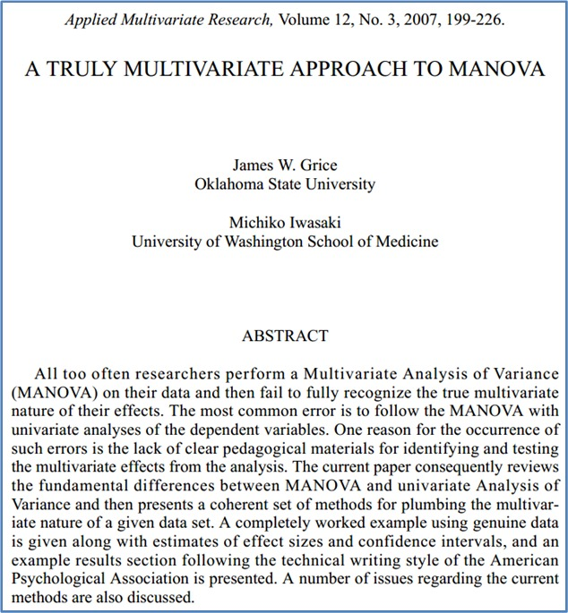

> GRICE & IWASAKI, 2007

### MANOVA robusta

Existe função para executar MANOVA utilizando *bootstrapping*, implementada em `demo_MANOVA_robusta.R`:

```
source("eiras.bartitle.R")

options(warn=-1) # disable warnings

cat(bartitle("Data"))
Dados <- readRDS("Adm2008.rds")
Dados <- Dados[, c("Sexo","Estatura","MCT")]

result <- MVN::mvn(data = Dados,
                   subset="Sexo",
                   # R=5e4,
                   # mvnTest = "energy",
                   mvnTest = "hz",
                   univariateTest = "SF",
                   showOutliers=TRUE)
print(result$multivariateNormality)
print(result$univariateNormality)
print(result$multivariateOutliers)

print(res <- heplots::boxM(Dados[,2:3], Dados[,1]))
plot(res, main="Adm2008")

# Robust One-way MANOVA (heterocedástica)
Dados.Mm <- as.matrix(subset(Dados, Sexo=="Masculino", select=c(Estatura, MCT)))
Dados.Fm <- as.matrix(subset(Dados, Sexo=="Feminino", select=c(Estatura, MCT)))
colMeans(Dados.Mm)
colMeans(Dados.Fm)
SHT::mean2.1980Johansen(Dados.Mm, Dados.Fm)

# Robust One-way MANOVA (Bartlett Chi2) (heterocedástica e não-multinormal)
mnv <- rrcov::Wilks.test(x=Dados[,c("Estatura","MCT")],
                         grouping=Dados[,"Sexo"],
                         method="mcd",nrep=1e3)
print(mnv)
```

```
----
Data
----
$Feminino
           Test        HZ   p value MVN
1 Henze-Zirkler 0.2874337 0.8769151 YES

$Masculino
           Test       HZ    p value MVN
1 Henze-Zirkler 1.125764 0.01046938  NO

$Feminino
             Test  Variable Statistic   p value Normality
1 Shapiro-Francia Estatura     0.9819    0.6938    YES
2 Shapiro-Francia    MCT       0.9809    0.6575    YES

$Masculino
             Test  Variable Statistic   p value Normality
1 Shapiro-Francia Estatura     0.9872    0.7697    YES
2 Shapiro-Francia    MCT       0.9781    0.3907    YES

NULL

    Box's M-test for Homogeneity of Covariance Matrices

data:  Dados[, 2:3]
Chi-Sq (approx.) = 19.918, df = 3, p-value = 0.0001765
```

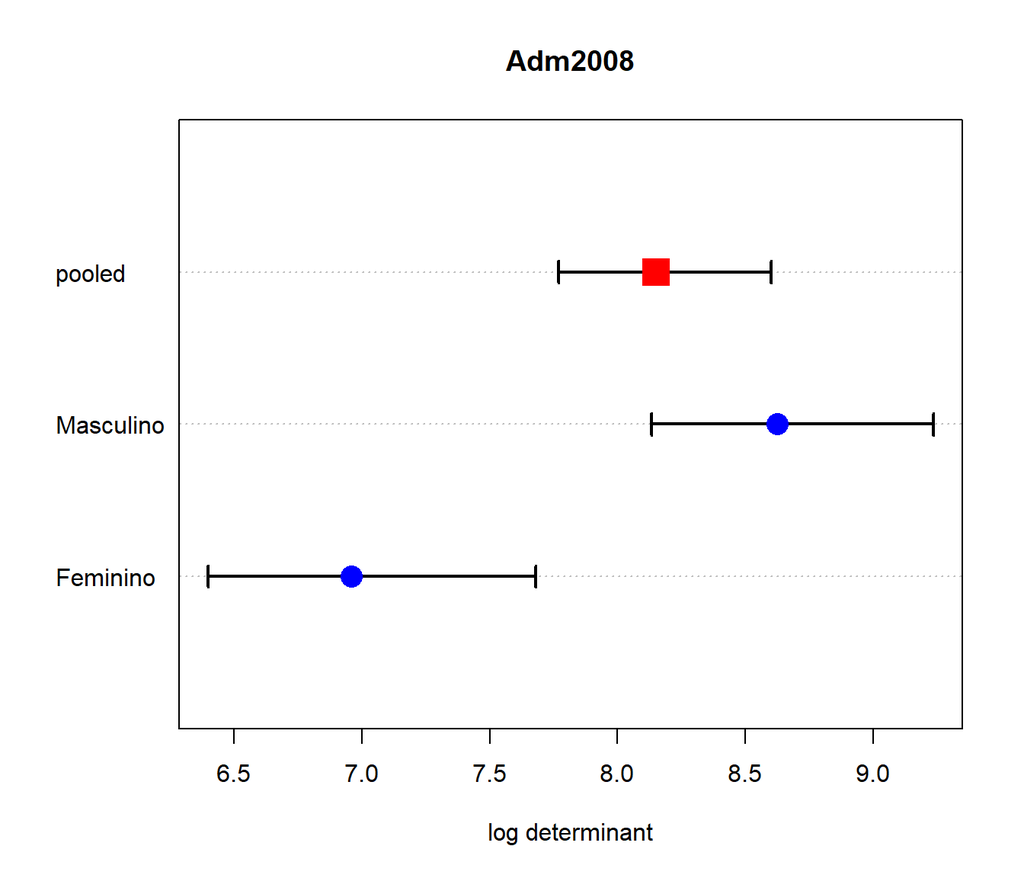

```
    Robust One-way MANOVA (Bartlett Chi2)

data:  x
Wilks' Lambda = 0.44685, Chi2-Value = 36.3982, DF = 1.6577, p-value =
6.643e-09
sample estimates:
          Estatura      MCT
Feminino  163.7568 54.72973
Masculino 176.8182 72.29545
```

A função `rrcov::Wilks.test` computa a MANOVA reportando apenas o $\lambda$ de Wilks, que corresponde a $1-\eta^2_{\text{pacial}}$ e rejeita-se a hipótese nula de igualdade de compleição entre homens e mulheres deste exemplo.

## MANOVA com três ou mais condições independentes

O $T^2$ de Hotelling permite duas ou mais medidas, mas o fator é limitado em dois grupos. MANOVA (assim como *t* em relação à one-way ANOVA) permite mais de dois grupos. Para exemplificar, usaremos o famoso arquivo [`iris`](https://pt.wikipedia.org/wiki/Conjunto_de_dados_flor_Iris), usando código similar ao anterior.

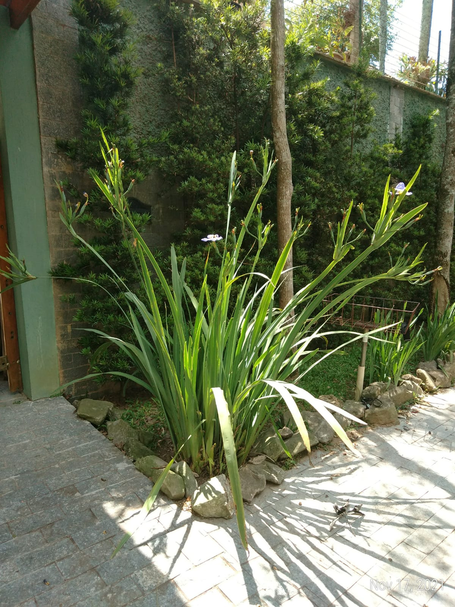

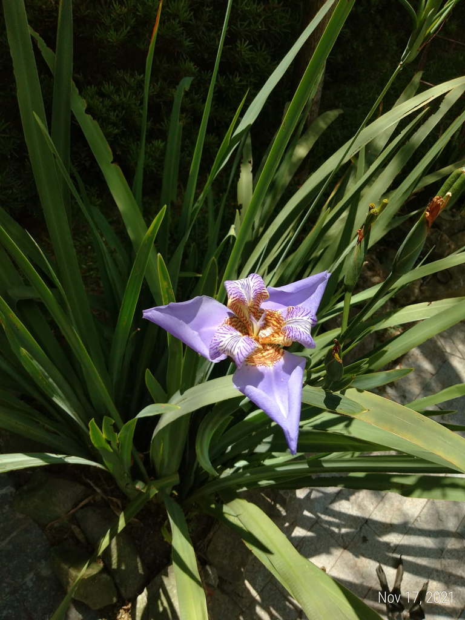

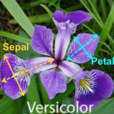

Estes dados estão sempre disponíveis no RStudio (veja a documentação com `?iris`) e contém as medidas de comprimento e largura de sépalas e pétalas (quatro medidas) de flores de três espécies de *Iris sp* (fator com três níveis: *setosa*, *versicolor* e *virginica*).

A estatística descritiva está implementada em `demo_iris_descritiva.R`:

```
options(warn=-1) # disable warnings

source("eiras.friendlycolor.R")
source("eiras.correg.R")
source("eiras.bivCI.R")
source("eiras.showdataframe.R")
source("eiras.numeric.summary.R")
source("eiras.bartitle.R")

colM <- friendlycolor(7) # azul
colF <- friendlycolor(30) # vermelho
pchM <- 24
pchF <- 21
alpha <- 0.05

cat(bartitle("Data"))
showdataframe(iris, head=5, tail=3)

cat(bartitle("Summary"))
print(
psych::describeBy(iris[,c("Sepal.Length","Sepal.Width",
                           "Petal.Length","Petal.Width")],
                  group=iris$Species,
                  mat=1,
                  digits=2)
)

cat(bartitle("Correlation & covariance"))
species <- unique(iris$Species)
colors <- c("#666666","#888888","#cccccc")
for (s in species)
{
  cat(bartitle(s,2))
  cat(bartitle("Correlation matrix",3))
  print(cor(subset(iris,Species=s,select=-Species)), digits=2)
  cat(bartitle("Covariance matrix",3))
  print(cov(subset(iris,Species=s,select=-Species)), digits=2)
}

Dados.long <- reshape2::melt(iris,
```

[output cut: 61 more lines]

```
    {
      dt_tmp2 <- dt_tmp[dt_tmp[3]==as.character(species[s]),c(1,2)]
      lines(bivCI(s = var(dt_tmp2),
                  xbar = colMeans(dt_tmp2),
                  n = nrow(dt_tmp2),
                  alpha = alpha/3, m = 10000),
            type = "l", col = colors[s], lwd = 2)
      cx <- mean(dt_tmp2[,1], na.rm=TRUE)
      cy <- mean(dt_tmp2[,2], na.rm=TRUE)
      points(cx,cy,pch=21,col=colors[s],bg=colors[s])
    }
  }
}

options(warn=0) # enable warnings
```

```
----
Data
----
 Sepal.Length Sepal.Width Petal.Length Petal.Width Species
 5.1          3.5         1.4          0.2         setosa
 4.9          3           1.4          0.2         setosa
 4.7          3.2         1.3          0.2         setosa
 4.6          3.1         1.5          0.2         setosa
 5            3.6         1.4          0.2         setosa
 ...          ...         ...          ...         ...
 6.5          3           5.2          2           virginica
 6.2          3.4         5.4          2.3         virginica
 5.9          3           5.1          1.8         virginica

-------
Summary
-------
              item     group1 vars  n mean   sd median trimmed  mad min max
Sepal.Length1    1     setosa    1 50 5.01 0.35   5.00    5.00 0.30 4.3 5.8
Sepal.Length2    2 versicolor    1 50 5.94 0.52   5.90    5.94 0.52 4.9 7.0
Sepal.Length3    3  virginica    1 50 6.59 0.64   6.50    6.57 0.59 4.9 7.9
Sepal.Width1     4     setosa    2 50 3.43 0.38   3.40    3.42 0.37 2.3 4.4
Sepal.Width2     5 versicolor    2 50 2.77 0.31   2.80    2.78 0.30 2.0 3.4
Sepal.Width3     6  virginica    2 50 2.97 0.32   3.00    2.96 0.30 2.2 3.8
Petal.Length1    7     setosa    3 50 1.46 0.17   1.50    1.46 0.15 1.0 1.9
Petal.Length2    8 versicolor    3 50 4.26 0.47   4.35    4.29 0.52 3.0 5.1
Petal.Length3    9  virginica    3 50 5.55 0.55   5.55    5.51 0.67 4.5 6.9
Petal.Width1    10     setosa    4 50 0.25 0.11   0.20    0.24 0.00 0.1 0.6
Petal.Width2    11 versicolor    4 50 1.33 0.20   1.30    1.32 0.22 1.0 1.8
Petal.Width3    12  virginica    4 50 2.03 0.27   2.00    2.03 0.30 1.4 2.5
              range  skew kurtosis   se
Sepal.Length1   1.5  0.11    -0.45 0.05
Sepal.Length2   2.1  0.10    -0.69 0.07
Sepal.Length3   3.0  0.11    -0.20 0.09
Sepal.Width1    2.1  0.04     0.60 0.05
Sepal.Width2    1.4 -0.34    -0.55 0.04
Sepal.Width3    1.6  0.34     0.38 0.05
Petal.Length1   0.9  0.10     0.65 0.02
Petal.Length2   2.1 -0.57    -0.19 0.07
Petal.Length3   2.4  0.52    -0.37 0.08
```

[output cut: 58 more lines]

```
        ------------------
             Sepal.Length Sepal.Width Petal.Length Petal.Width
Sepal.Length         1.00       -0.12         0.87        0.82
Sepal.Width         -0.12        1.00        -0.43       -0.37
Petal.Length         0.87       -0.43         1.00        0.96
Petal.Width          0.82       -0.37         0.96        1.00

        -----------------
        Covariance matrix
        -----------------
             Sepal.Length Sepal.Width Petal.Length Petal.Width
Sepal.Length        0.686      -0.042         1.27        0.52
Sepal.Width        -0.042       0.190        -0.33       -0.12
Petal.Length        1.274      -0.330         3.12        1.30
Petal.Width         0.516      -0.122         1.30        0.58
```

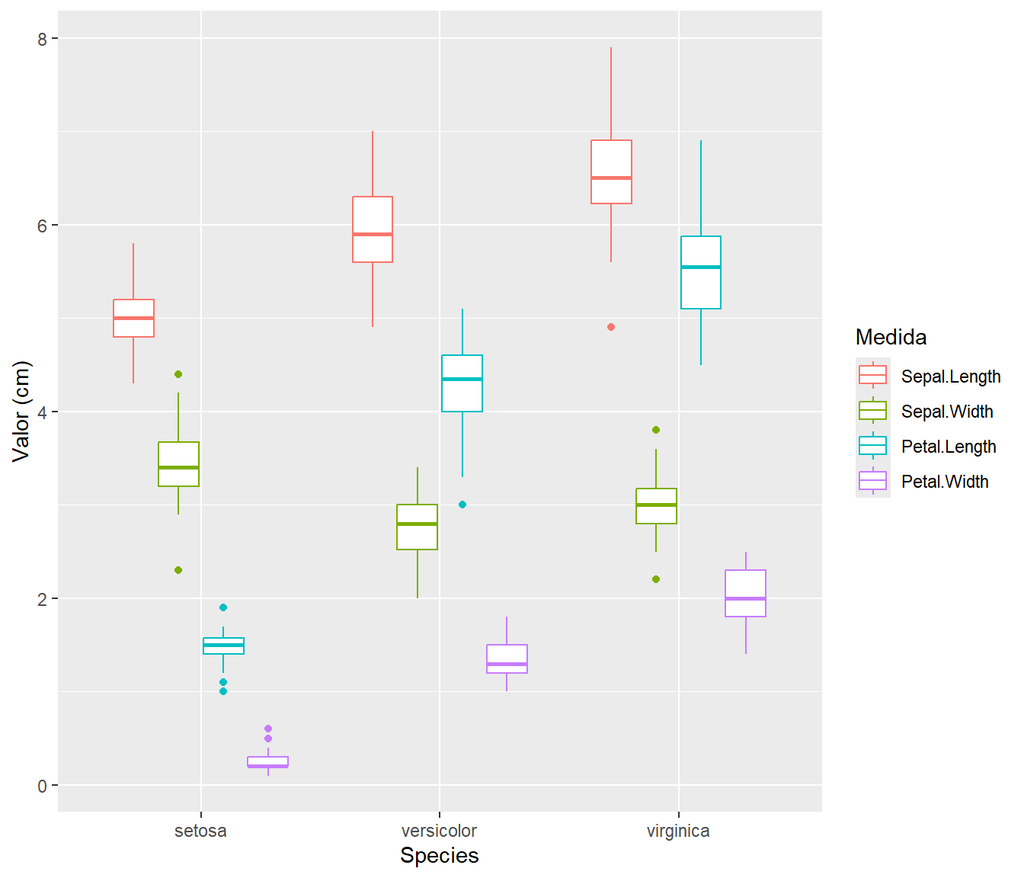

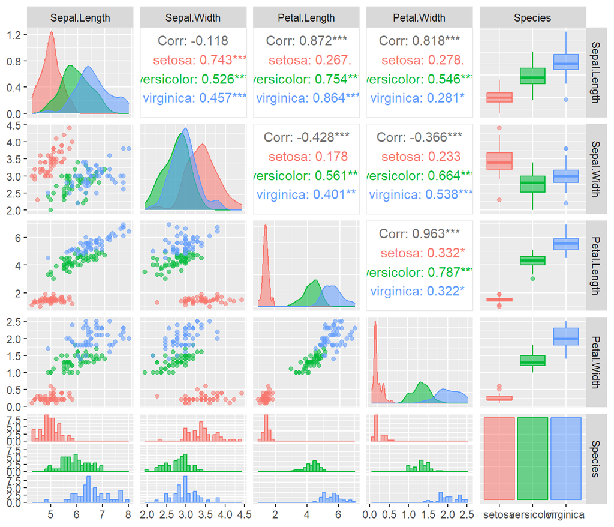

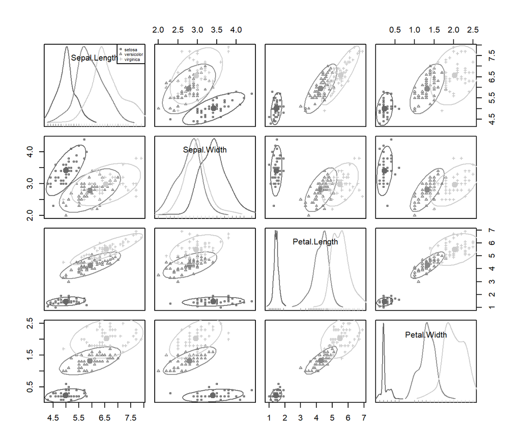

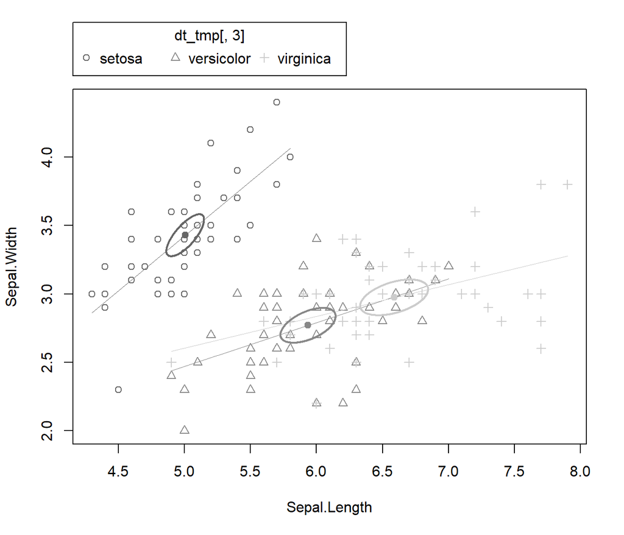

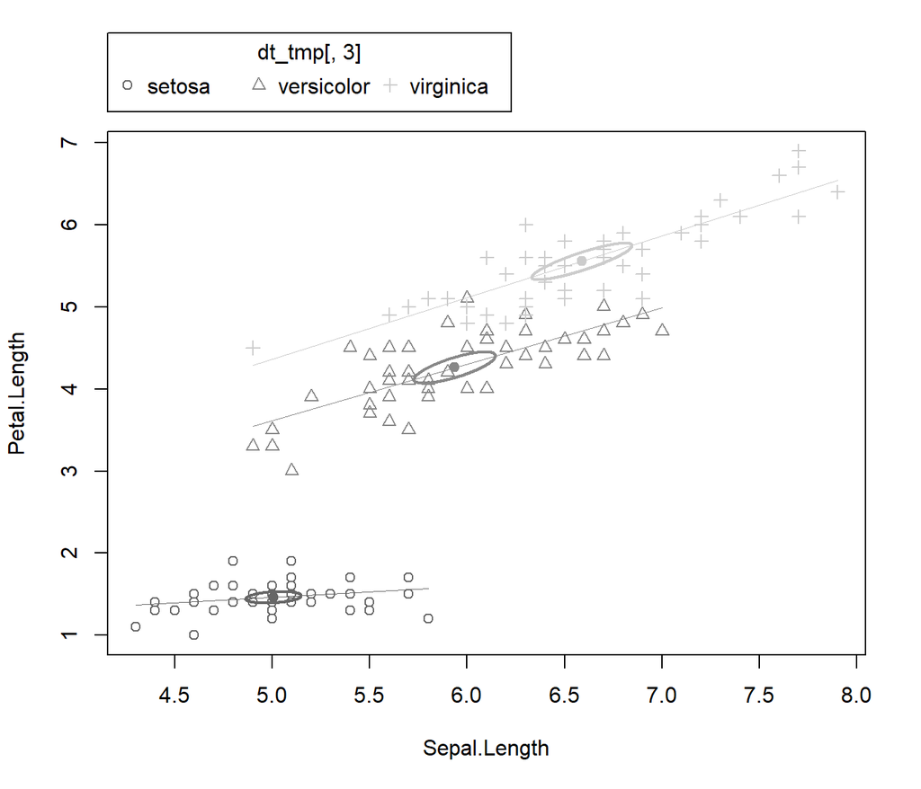

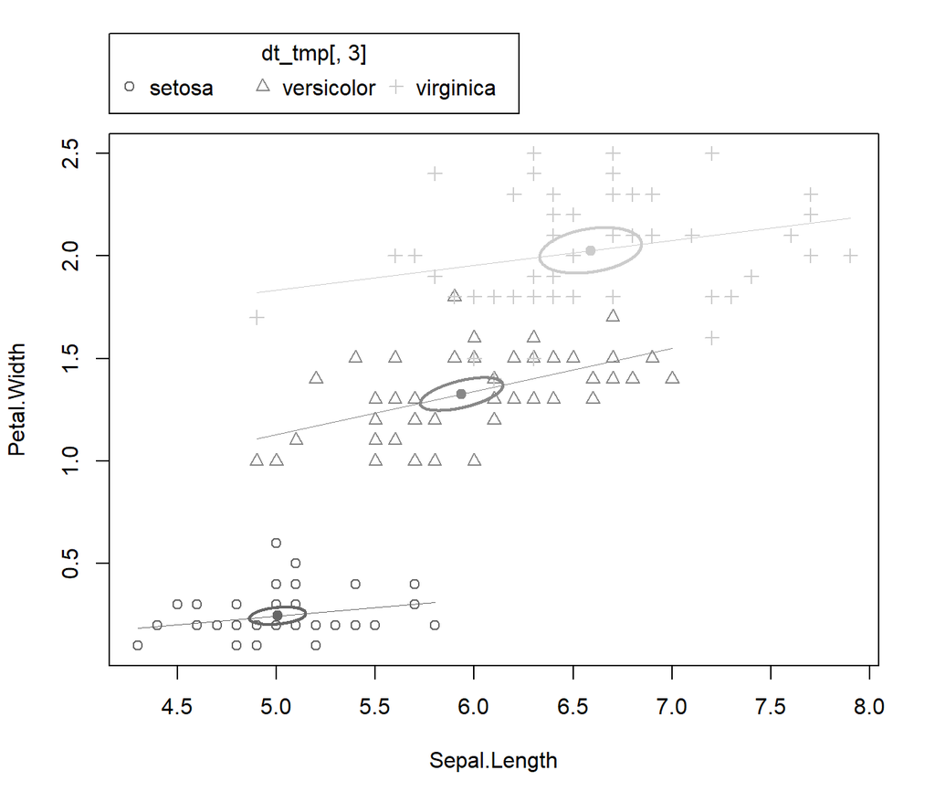

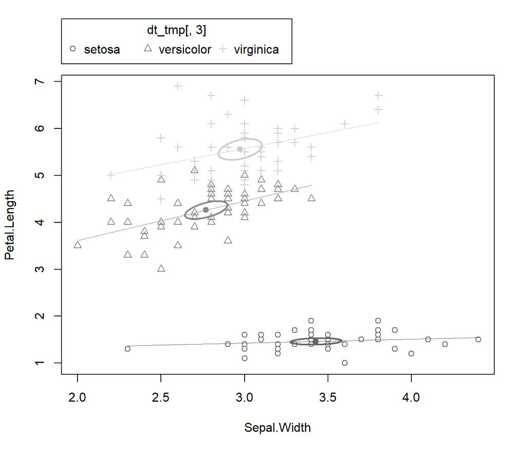

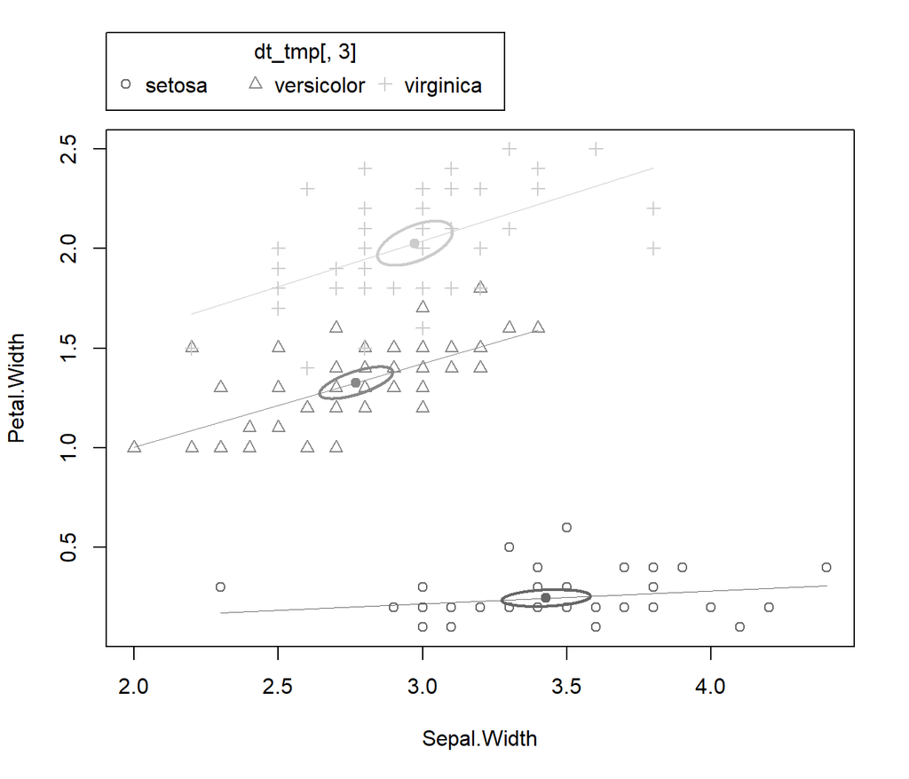

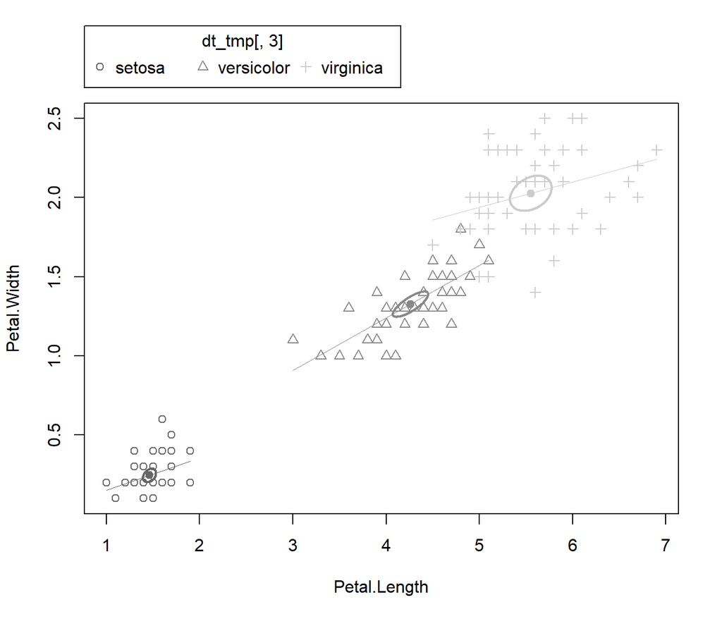

Uma das novidades que aparece nesta saída é o gráfico produzido pela função `car::scatterplotMatrix` que exibe *density plots* na diagonal principal e *scatterplots* para as combinações dois a dois das quatro medidas. Estes dados estão associados com elipses de predição de 95% dos pontos observados.

### Suposições

#### Normalidade univariada e multivariada

Implementado em `demo_iris_normalidade.R`:

```
source("eiras.bartitle.R")

options(warn=-1) # disable warnings
data(iris)
result <- MVN::mvn(data = iris,
                   subset="Species",
                   # R=5e4,
                   # mvnTest = "energy",
                   mvnTest = "hz",
                   univariateTest = "SF",
                   showOutliers=TRUE)
print(result$multivariateNormality)
print(result$univariateNormality)
print(result$multivariateOutliers)

options(warn=0) # enable warnings
```

```
$setosa
           Test        HZ    p value MVN
1 Henze-Zirkler 0.9488453 0.04995356  NO

$versicolor
           Test        HZ   p value MVN
1 Henze-Zirkler 0.8388009 0.2261991 YES

$virginica
           Test        HZ   p value MVN
1 Henze-Zirkler 0.7570095 0.4970237 YES

$setosa
             Test     Variable Statistic   p value Normality
1 Shapiro-Francia Sepal.Length    0.9817  0.5357      YES
2 Shapiro-Francia Sepal.Width     0.9641  0.1181      YES
3 Shapiro-Francia Petal.Length    0.9490  0.0324      NO
4 Shapiro-Francia Petal.Width     0.7952  <0.001      NO

$versicolor
             Test     Variable Statistic   p value Normality
1 Shapiro-Francia Sepal.Length    0.9836    0.6153    YES
2 Shapiro-Francia Sepal.Width     0.9763    0.3462    YES
3 Shapiro-Francia Petal.Length    0.9678    0.1643    YES
4 Shapiro-Francia Petal.Width     0.9529    0.0448    NO

$virginica
             Test     Variable Statistic   p value Normality
1 Shapiro-Francia Sepal.Length    0.9712    0.2210    YES
2 Shapiro-Francia Sepal.Width     0.9643    0.1205    YES
3 Shapiro-Francia Petal.Length    0.9652    0.1301    YES
4 Shapiro-Francia Petal.Width     0.9656    0.1354    YES

NULL
```

#### Homocedasticidade multivariada

Avaliamos a homogeneidade das matrizes de covariância. Implementado em `demo_iris_homocedasticidade.R`:

```
source("eiras.bartitle.R")

options(warn=-1) # disable warnings

print(res <- heplots::boxM(iris[,1:4], iris$Species))
plot(res, main="Iris")

options(warn=0) # enable warnings
```

```
    Box's M-test for Homogeneity of Covariance Matrices

data:  iris[, 1:4]
Chi-Sq (approx.) = 140.94, df = 20, p-value < 2.2e-16
```

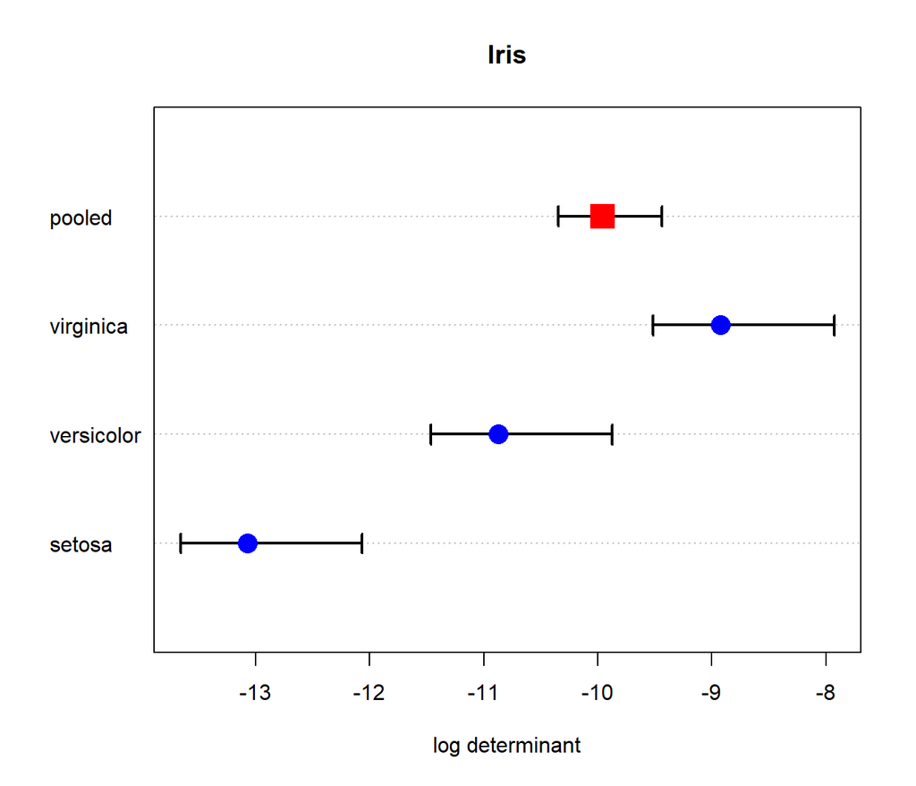

Apesar de ser heterocedástico, os grupos são perfeitamente balanceados e, por isso, podemos prosseguir com a MANOVA.

### Aplicação do teste

Implementado em `demo_MANOVA_iris.R`:

```
source("eiras.bartitle.R")
options(warn=-1) # disable warnings

cat(bartitle("MANOVA"))
cat(bartitle("Tabela ANOVA da MANOVA",2))
fit <- manova(cbind(Sepal.Length,Sepal.Width,
                    Petal.Length,Petal.Width) ~ Species,
              data=iris)
print(anv <- car::Anova(fit,
                        test="Pillai"),
      digits=3)
alpha <- 0.05
eta2 <- effectsize::eta_squared(anv,
                                partial=TRUE,
                                generalized=FALSE,
                                ci=1-alpha,
                                alternative="two.sided",
                                verbose=TRUE)
eta2$interpret <- effectsize::interpret_eta_squared(eta2$Eta2)
print(eta2, digits=2)
```

```
------
MANOVA
------

    ----------------------
    Tabela ANOVA da MANOVA
    ----------------------

Type II MANOVA Tests: Pillai test statistic
        Df test stat approx F num Df den Df Pr(>F)
Species  2      1.19     53.5      8    290 <2e-16 ***
---
Signif. codes:  0 '***' 0.001 '**' 0.01 '*' 0.05 '.' 0.1 ' ' 1
# Effect Size for ANOVA (Type II)

Parameter | Eta2 (partial) |       95% CI | interpret
-----------------------------------------------------
Species   |           0.60 | [0.52, 0.65] |     large
```

Pelo teste de Pillai, rejeita-se $H_0$.

#### Testes *post hoc*

A forma adequada de fazer o teste é comparar os grupos dois a dois mas considerando conjuntamente todas as medidas usadas para o teste *omnibus*. Implementado em `demo_MANOVA_iris_posthoc.R`:

```
# Testes post hoc
source("eiras.bartitle.R")
alpha <- 0.05
# setosa & versicolor
cat(bartitle("setosa & versicolor"))
Dados1 <- subset(iris, Species!="virginica")
fit <- manova(cbind(Sepal.Length, Sepal.Width,
                    Petal.Length, Petal.Width) ~ Species,
              data=Dados1)
print(anv <- car::Anova(fit,
                        test="Pillai"),
      digits=3)
eta2 <- effectsize::eta_squared(anv,
                                partial=TRUE,
                                generalized=FALSE,
                                ci=1-alpha,
                                alternative="two.sided",
                                verbose=TRUE)
eta2$interpret <- effectsize::interpret_eta_squared(eta2$Eta2)
print(eta2, digits=2)

# setosa & virginica
cat(bartitle("setosa & virginica"))
Dados2 <- subset(iris, Species!="versicolor")
fit <- manova(cbind(Sepal.Length, Sepal.Width,
                    Petal.Length, Petal.Width) ~ Species,
              data=Dados2)
print(anv <- car::Anova(fit,
                        test="Pillai"),
      digits=3)
eta2 <- effectsize::eta_squared(anv,
                                partial=TRUE,
                                generalized=FALSE,
                                ci=1-alpha,
                                alternative="two.sided",
                                verbose=TRUE)
eta2$interpret <- effectsize::interpret_eta_squared(eta2$Eta2)
print(eta2, digits=2)

# versicolor & virginica
cat(bartitle("versicolor & virginica"))
Dados3 <- subset(iris, Species!="setosa")
fit <- manova(cbind(Sepal.Length, Sepal.Width,
                    Petal.Length, Petal.Width) ~ Species,
              data=Dados3)
print(anv <- car::Anova(fit,
                        test="Pillai"),
      digits=3)
eta2 <- effectsize::eta_squared(anv,
                                partial=TRUE,
                                generalized=FALSE,
                                ci=1-alpha,
                                alternative="two.sided",
                                verbose=TRUE)
eta2$interpret <- effectsize::interpret_eta_squared(eta2$Eta2)
print(eta2, digits=2)
```

```
-------------------
setosa & versicolor
-------------------

Type II MANOVA Tests: Pillai test statistic
        Df test stat approx F num Df den Df Pr(>F)
Species  1     0.963      625      4     95 <2e-16 ***
---
Signif. codes:  0 '***' 0.001 '**' 0.01 '*' 0.05 '.' 0.1 ' ' 1
# Effect Size for ANOVA (Type II)

Parameter | Eta2 (partial) |       95% CI | interpret
-----------------------------------------------------
Species   |           0.96 | [0.95, 0.97] |     large

------------------
setosa & virginica
------------------

Type II MANOVA Tests: Pillai test statistic
        Df test stat approx F num Df den Df Pr(>F)
Species  1      0.98     1183      4     95 <2e-16 ***
---
Signif. codes:  0 '***' 0.001 '**' 0.01 '*' 0.05 '.' 0.1 ' ' 1
# Effect Size for ANOVA (Type II)

Parameter | Eta2 (partial) |       95% CI | interpret
-----------------------------------------------------
Species   |           0.98 | [0.97, 0.98] |     large

----------------------
versicolor & virginica
----------------------

Type II MANOVA Tests: Pillai test statistic
        Df test stat approx F num Df den Df Pr(>F)
Species  1     0.784     86.1      4     95 <2e-16 ***
---
Signif. codes:  0 '***' 0.001 '**' 0.01 '*' 0.05 '.' 0.1 ' ' 1
# Effect Size for ANOVA (Type II)

Parameter | Eta2 (partial) |       95% CI | interpret
-----------------------------------------------------
Species   |           0.78 | [0.71, 0.83] |     large
```

Utilizando correção de Bonferroni para o nível de significância de 5% (i.e., $\alpha \approx 0.0167$), conclui-se que os tamanhos totais das três espécies são diferentes.

Podemos imaginar como indicador o produto do comprimento e largura das pétalas e sépalas (que são uma aproximação das respectivas áreas) para colocar as flores das três espécies em ordem de tamanho:

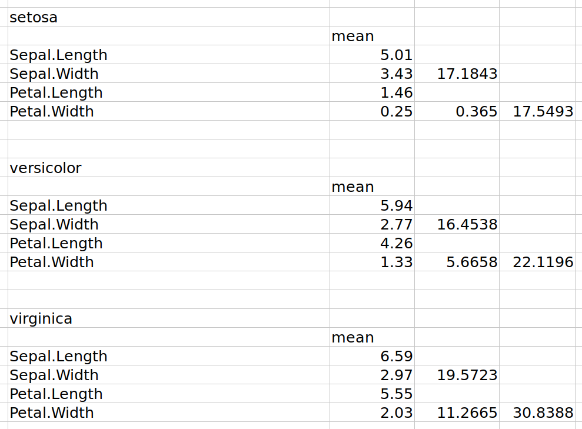

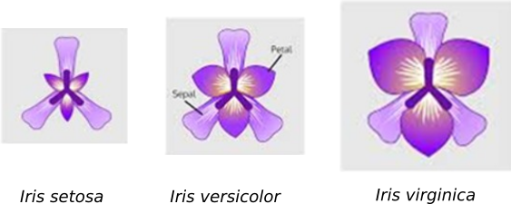

### MANOVA robusta

```
source("eiras.bartitle.R")

options(warn=-1) # disable warnings

cat(bartitle("MANOVA robusta"))
mnv <- rrcov::Wilks.test(x=iris[,1:4],
                          grouping=iris[,"Species"],
                          method="mcd",nrep=1e3)
print(mnv)
data(iris)
result <- MVN::mvn(data = iris,
                   subset="Species",
                   # R=5e4,
                   # mvnTest = "energy",
                   mvnTest = "hz",
                   univariateTest = "SF")
print(result$multivariateNormality)
print(result$univariateNormality)

print(res <- heplots::boxM(iris[,1:4], iris[,"Species"]))
plot(res, main="Iris")

# Robust One-way MANOVA (Bartlett Chi2) (heterocedástica e não-multinormal)
mnv <- rrcov::Wilks.test(x=iris[,1:4],
                         grouping=iris[,"Species"],
                         method="mcd",nrep=1e3)
print(mnv)
```

```
--------------
MANOVA robusta
--------------

    Robust One-way MANOVA (Bartlett Chi2)

data:  x
Wilks' Lambda = 0.012731, Chi2-Value = 456.859, DF = 7.517, p-value <
2.2e-16
sample estimates:
           Sepal.Length Sepal.Width Petal.Length Petal.Width
setosa         4.985106    3.419149     1.470213   0.2425532
versicolor     5.953191    2.768085     4.257447   1.3148936
virginica      6.452941    2.985294     5.402941   2.0676471

$setosa
           Test        HZ    p value MVN
1 Henze-Zirkler 0.9488453 0.04995356  NO

$versicolor
           Test        HZ   p value MVN
1 Henze-Zirkler 0.8388009 0.2261991 YES

$virginica
           Test        HZ   p value MVN
1 Henze-Zirkler 0.7570095 0.4970237 YES

$setosa
             Test     Variable Statistic   p value Normality
1 Shapiro-Francia Sepal.Length    0.9817  0.5357      YES
2 Shapiro-Francia Sepal.Width     0.9641  0.1181      YES
3 Shapiro-Francia Petal.Length    0.9490  0.0324      NO
4 Shapiro-Francia Petal.Width     0.7952  <0.001      NO

$versicolor
             Test     Variable Statistic   p value Normality
1 Shapiro-Francia Sepal.Length    0.9836    0.6153    YES
2 Shapiro-Francia Sepal.Width     0.9763    0.3462    YES
3 Shapiro-Francia Petal.Length    0.9678    0.1643    YES
4 Shapiro-Francia Petal.Width     0.9529    0.0448    NO

$virginica
             Test     Variable Statistic   p value Normality
1 Shapiro-Francia Sepal.Length    0.9712    0.2210    YES
2 Shapiro-Francia Sepal.Width     0.9643    0.1205    YES
3 Shapiro-Francia Petal.Length    0.9652    0.1301    YES
4 Shapiro-Francia Petal.Width     0.9656    0.1354    YES


    Box's M-test for Homogeneity of Covariance Matrices

data:  iris[, 1:4]
Chi-Sq (approx.) = 140.94, df = 20, p-value < 2.2e-16
```

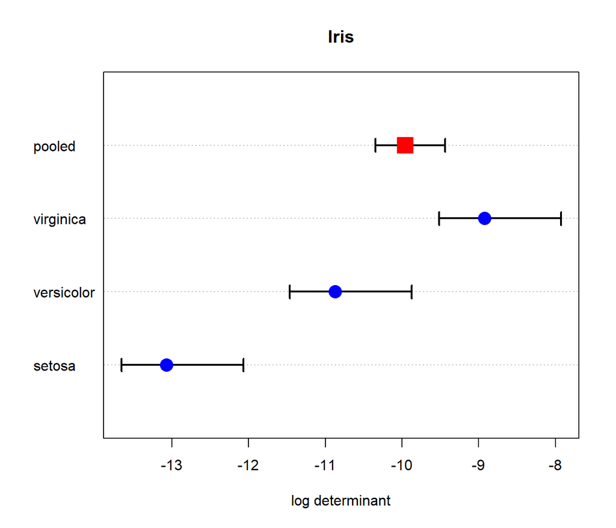

```
    Robust One-way MANOVA (Bartlett Chi2)

data:  x
Wilks' Lambda = 0.013115, Chi2-Value = 442.7819, DF = 7.4062, p-value <
2.2e-16
sample estimates:
           Sepal.Length Sepal.Width Petal.Length Petal.Width
setosa         4.985106    3.419149     1.470213   0.2425532
versicolor     5.946809    2.789362     4.263830   1.3212766
virginica      6.415152    2.984848     5.381818   2.0606061
```

A conclusão é a mesma neste exemplo.

# MANCOVA

Retomando o exemplo da estatura e MCT dos estudantes de administração, podemos controlar por uma covariável intervalar que, neste exemplo, é a idade. Implementamos em `demo_MANCOVA.R`:

```
source("eiras.bartitle.R")

options(warn=-1) # disable warnings

Dados <- readRDS("Adm2008.rds")

cat(bartitle("MANCOVA"))

fit <- manova(cbind(Estatura,MCT)~Sexo+Idade,
              data=Dados)
print(anv <- car::Anova(fit,
                        univariate=FALSE,
                        multivariate=TRUE,
                        test="Pillai"),
      digits=3)
alpha <- 0.05
eta2 <- effectsize::eta_squared(anv,
                                partial=TRUE,
                                generalized=FALSE,
                                ci=1-alpha,
                                alternative="two.sided",
                                verbose=TRUE)
eta2$interpret <- effectsize::interpret_eta_squared(eta2$Eta2)
print(eta2, digits=2)
```

```
-------
MANCOVA
-------

Type II MANOVA Tests: Pillai test statistic
      Df test stat approx F num Df den Df Pr(>F)
Sexo   1     0.478     38.9      2     85  1e-12 ***
Idade  1     0.135      6.7      2     85 0.0021 **
---
Signif. codes:  0 '***' 0.001 '**' 0.01 '*' 0.05 '.' 0.1 ' ' 1
# Effect Size for ANOVA (Type II)

Parameter | Eta2 (partial) |       95% CI | interpret
-----------------------------------------------------
Sexo      |           0.48 | [0.32, 0.59] |     large
Idade     |           0.14 | [0.02, 0.27] |    medium
```

O valor *p* que interessa é o que está associado com `Sexo` e, portanto, rejeita-se $H_0$. A MANCOVA é, simplesmente, feita com

`manova(cbind(Estatura, MCT) ~ Sexo + Idade, data=Dados)`

A VD é a composição `cbind(Estatura, MCT)` e a `Idade` é adicionada como covariável, da mesma forma que foi feito na ANCOVA.

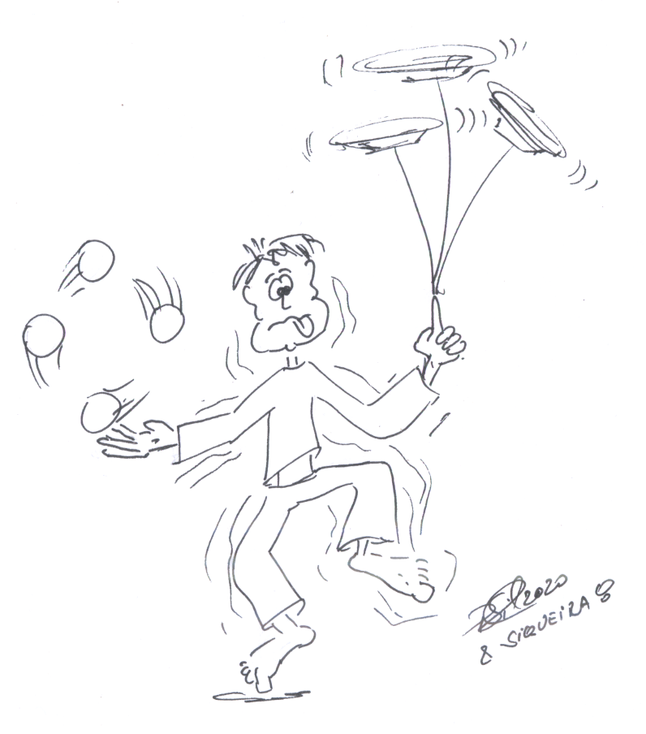

# Referências

- Borm, GF et al. (2007) A simple sample size formula for analysis of covariance in randomized clinical trials. *Journal of Clinical Epidemiology* 60: 1234-8.
- Crawley, MJ (2012) *The R Book*. 2nd ed.
- Grice, JW & Iwasaki, M (2007) A truly multivariate approach to MANOVA. *Applied Multivariate Research* 12(30): 199-226.
- Johnson, R & Wichern, D (2007) *Applied Multivariate Statistical Analysis*. 6ª ed. NJ: Prentice-Hall.
- Lin, W-Y (1992) An Overview of the Performance of Four Alternatives to Hotelling’s T Square. *Educational Research Journal* 7:110-114.
- Moreira, NF et al. (2018) Self-reported weight and height are valid measures to determine weight status: Results from the Brazilian National Health Survey (PNS 2013). *Cadernos de Saúde Pública* 34(5). https://doi.org/10.1590/0102-311x00063917
- Sakae, TM et al. (2016) Efeitos da anestesia geral da cognição do idoso. *Arquivos Catarinenses de Medicina* 45(3): 107-16.
- Xiaofeng, L (2011) The Effect of a Covariate on Standard Error and Confidence Interval Width. *Communications in Statistics: Theory and Methods* 40(3): 449-456, DOI: 10.1080/03610920903391337